# LESSON 6: SOFTMAX REGRESSION

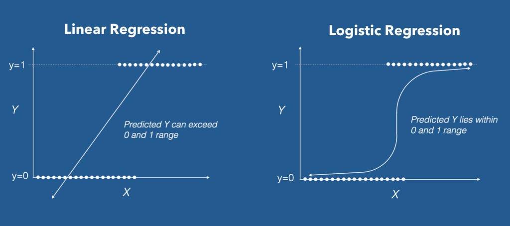

*This lecture was refered by [machinelearningcoban.com](https://machinelearningcoban.com/2017/02/17/softmax/)*

## 1. Softmax regression introduction

To solve multiple classes classification problem by using logistic regression, we have to build multiple logistic regression models. This model is called *one-vs-rest*.

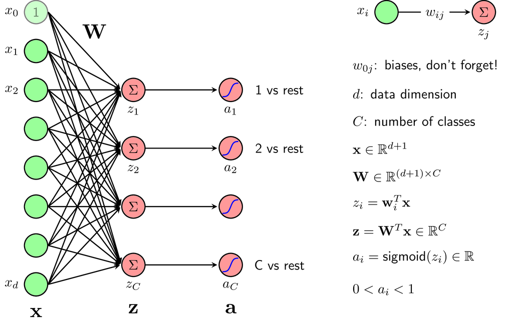

$a_i$ with i = 1, 2, 3 ... C are almost independent and their sum can be larger or smaller than 1.

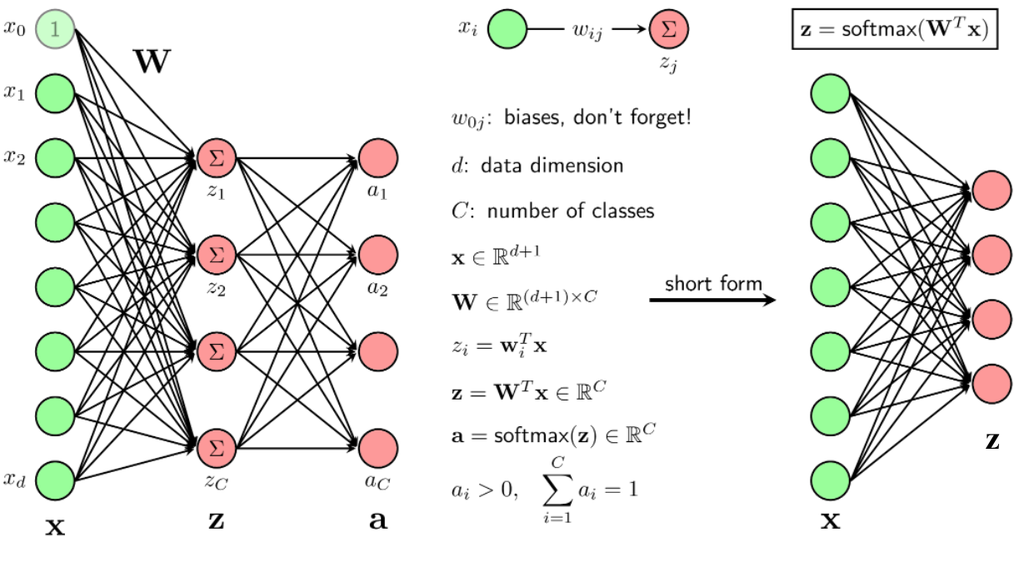

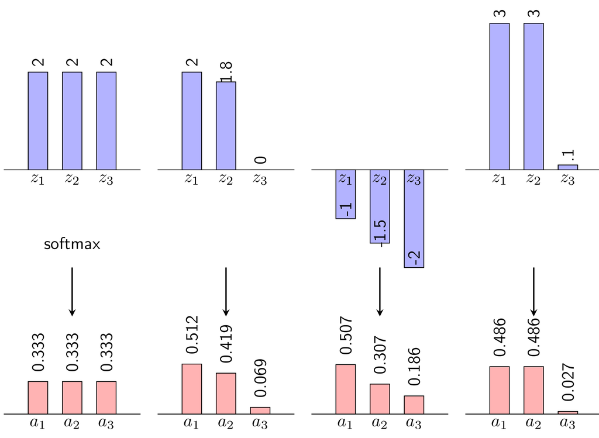

Because we have to calculate $e^{z_i}$, if $z_i$ is large, $e^{z_i}$ will be very large and it causes value out of range error. We need to build a stable version of softmax.

\[ softmax(z^i) = \frac{e^{z_i}}{\sum_j^C e^{z_j}} = \frac{e^{-max_j(z_j)} * e^{z_i}}{e^{-max_j(z_j)} * \sum_j^C e^{z_j}} = \frac{e^{z_i - max_j(z_j)}}{\sum_j^C e^{z_j - max_j(z_j)}} \]

## 2. Loss function and Optimizer for Softmax regression

Instead of having only 2 classes like logistic regression, softmax regression has C classes and it need another form of cross entropy loss function.

Its name is *CATEGORICAL CROSS ENTROPY*

\[ J(W; X, Y) = -\sum_{i=1}^N \sum_{j=1}^C y_{ji}\log(a_{ji}) = -\sum_{i=1}^N \sum_{j=1}^C y_{ji}\log\frac{e^{{z}_i}}{\sum_{k=1}^C e^{{z}_k}} \]

For each sample from the dataset,

\[ J({W}; {x}_i, {y}_i) = -\sum_{j=1}^C y_{ji}\log\frac{e^{{z}_ji}}{\sum_{k=1}^C e^{{z}_ki}} \\ = -\sum_{j=1}^C (y_{ji}{z}_ji - y_{ji}\log{\sum_{k=1}^C e^{{z}_ki}}) \\ = -\sum_{j=1}^C y_{ji}{z}_ji + \sum_{j=1}^C y_{ji}\log{\sum_{k=1}^C e^{{z}_ki}} \\ = -\sum_{j=1}^C y_{ji}{z}_ji + \log{\sum_{k=1}^C e^{{z}_ki}} \]

Note:

- $\sum_{j=1}^C y_{ji}=1$ because it's the sum of probability
- $\log{\sum_{k=1}^C e^{{z}_ki}}$ is independent with $j$ so we can remove $\sum_{j=1}^C$

To calculate derivative of $J$ with $W$, we can use the following fomular

\[ \frac{\partial J_i(W)}{\partial W} = [\frac{\partial J_i(W)}{\partial w_1}, \frac{\partial J_i(W)}{\partial w_2}, \dots, \frac{\partial J_i(W)}{\partial w_C}] \]

and gradient of each column can be calculated by

\[ \frac{\partial J_i(W)}{\partial w_j} = -y_{ji}x_i + \frac{e^{z_ji} x_i}{\sum_{k=1}^C e^{z_ki}} = -y_{ji}x_i + a_{ji} x_i = x_i (a_{ji} - y_{ji}) \]

Note:

- In the first equation, because we do derivative with $w_j$, all elements in $\sum_{k=1}^C e^{z_ki}$ are equal to 0 except $e^{z_ji}$
- $e_{ji} = a_{ji} - y_{ji}$ is the different between the prediction and the real value

Now, we have

\[ \frac{\partial J_i(W)}{\partial W} = x_i[e_{1i}, e_{1i}, \dots, e_{ji}] = x_i e_i \]

and for the whole dataset

\[ \frac{\partial J(W)}{\partial W} = \sum_{i=1}^N x_i e_{i} = XE \]

**To conclude, Logistic Regression is a special case of Softmax Regression!!!**

## 3. Implementation example

### 3.1. Prepare library and data

```python
import pandas as pd
import matplotlib.pyplot as plt
import numpy as np
import seaborn as sns
```

```python
iris_df = sns.load_dataset('iris')
iris_df
```

|  | sepal_length | sepal_width | petal_length | petal_width | species |
| --- | --- | --- | --- | --- | --- |
| 0 | 5.1 | 3.5 | 1.4 | 0.2 | setosa |
| 1 | 4.9 | 3.0 | 1.4 | 0.2 | setosa |
| 2 | 4.7 | 3.2 | 1.3 | 0.2 | setosa |
| 3 | 4.6 | 3.1 | 1.5 | 0.2 | setosa |
| 4 | 5.0 | 3.6 | 1.4 | 0.2 | setosa |
| ... | ... | ... | ... | ... | ... |
| 145 | 6.7 | 3.0 | 5.2 | 2.3 | virginica |
| 146 | 6.3 | 2.5 | 5.0 | 1.9 | virginica |
| 147 | 6.5 | 3.0 | 5.2 | 2.0 | virginica |
| 148 | 6.2 | 3.4 | 5.4 | 2.3 | virginica |
| 149 | 5.9 | 3.0 | 5.1 | 1.8 | virginica |

150 rows × 5 columns

```python
df = iris_df.drop(columns=['sepal_length', 'sepal_width'])
df
```

|  | petal_length | petal_width | species |
| --- | --- | --- | --- |
| 0 | 1.4 | 0.2 | setosa |
| 1 | 1.4 | 0.2 | setosa |
| 2 | 1.3 | 0.2 | setosa |
| 3 | 1.5 | 0.2 | setosa |
| 4 | 1.4 | 0.2 | setosa |
| ... | ... | ... | ... |
| 145 | 5.2 | 2.3 | virginica |
| 146 | 5.0 | 1.9 | virginica |
| 147 | 5.2 | 2.0 | virginica |
| 148 | 5.4 | 2.3 | virginica |
| 149 | 5.1 | 1.8 | virginica |

150 rows × 3 columns

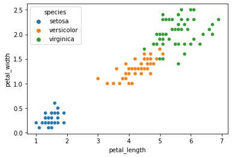

```python
sns.scatterplot(data=df, x='petal_length', y='petal_width', hue='species')
plt.show()
```

```python
df
```

|  | petal_length | petal_width | species |
| --- | --- | --- | --- |
| 0 | 1.4 | 0.2 | setosa |
| 1 | 1.4 | 0.2 | setosa |
| 2 | 1.3 | 0.2 | setosa |
| 3 | 1.5 | 0.2 | setosa |
| 4 | 1.4 | 0.2 | setosa |
| ... | ... | ... | ... |
| 145 | 5.2 | 2.3 | virginica |
| 146 | 5.0 | 1.9 | virginica |
| 147 | 5.2 | 2.0 | virginica |
| 148 | 5.4 | 2.3 | virginica |
| 149 | 5.1 | 1.8 | virginica |

150 rows × 3 columns

```python
def prepare_X_ones(X):
    x_1 = np.ones((1, X.shape[1]))
    print('x_0.shape', x_1.shape)

    X = np.concatenate((x_1, X), axis=0).T
    print('X.shape', X.shape)

    return X
```

```python
X = df.iloc[:, :2].T
X.shape
```

```
(2, 150)
```

```python
X = prepare_X_ones(X)
X.shape
```

```
x_0.shape (1, 150)
X.shape (150, 3)
```

```
(150, 3)
```

```python
y = df.species
y.shape
```

```
(150,)
```

```python
def one_hot_encode(y):
    y_one_hot = []
    y_index = []

    for label in y:
        if label == 'setosa':
            y_one_hot.append([1, 0, 0])
            y_index.append(0)
        elif label == 'versicolor':
            y_one_hot.append([0, 1, 0])
            y_index.append(1)
        elif label == 'virginica':
            y_one_hot.append([0, 0, 1])
            y_index.append(2)

    return np.array(y_one_hot), np.array(y_index)
```

```python
y_one_hot, y_index = one_hot_encode(y)
y_one_hot.shape
```

```
(150, 3)
```

```python
num_classes = y_one_hot.shape[1]
num_classes
```

```
3
```

### 3.2. Implement from scratch

```python
class MySoftmaxRegression():

    def __init__(self, max_iter, num_classes):
        self.max_iter = max_iter
        self.num_classes = num_classes

    def __call__(self, X, y, lr):
        # Init randomly weights
        w_init = np.random.randn(X.shape[1], self.num_classes)
        w = [w_init]

        count = 0
        while count < self.max_iter:
            # Shuffle dataset to run SGD
            for i in np.random.permutation(X.shape[0]):
                x_i = X[i, :].reshape(1, X.shape[1])

                # Calculate logistic regression
                z_i = self.softmax(x_i.dot(w[-1]))


                # Calculate grad and update weights
                y_i = y[i].reshape(1, y[i].shape[0])
                w_new = w[-1] - lr * x_i.T.dot(z_i - y_i)

                count += 1

                # Stopping criteria
                if count % 20 == 0:
                    if np.linalg.norm(w_new - w[-20]) < 1e-4:
                        self.w = w[-1]
                        return

                w.append(w_new)
        self.w = w[-1]

    @staticmethod
    def softmax(z):
        e_z = np.exp(z)
        A = e_z / np.expand_dims(np.sum(e_z, axis=1), 1)
        return A

    def predict(self, X):
        pred_proba = self.softmax(X.dot(self.w))
        pred = np.argmax(pred_proba, axis=1)
        return pred_proba, pred

    def display(self, X, y, w=None):

        reg_x = np.linspace(1, 7, 2)
        for index in range(self.num_classes):
            reg_y = \
            (- self.w[0][index] / self.w[2][index]) + \
            (- self.w[1][index] / self.w[2][index]) * reg_x
            plt.plot(reg_x, reg_y, 'y-')

        plt.plot(X[:50, 1], X[:50, 2], 'ro')
        plt.plot(X[50:100, 1], X[50:100, 2], 'go')
        plt.plot(X[100:, 1], X[100:, 2], 'bo')

        if w is not None:
            for index in range(self.num_classes):
                reg_y = \
                (- w[0][index] / w[2][index]) + \
                (- w[1][index] / w[2][index]) * reg_x
                plt.plot(reg_x, reg_y, 'k-')

        plt.xlabel('sepal_length')
        plt.ylabel('sepal_width')
        plt.xlim(0.5, 7.5)
        plt.ylim(0, 4)
        plt.show()
```

```python
my_softmax_regression = MySoftmaxRegression(
    max_iter=10000,
    num_classes=num_classes
)
```

```python
my_softmax_regression(
    X=X,
    y=y_one_hot,
    lr=0.01
)
```

```python
my_softmax_regression.w
```

```
array([[ 4.6171989 , -0.65906317, -4.42703628],
       [-1.9618402 ,  0.15962902, -0.18807667],
       [-0.33678468, -0.5938621 ,  2.63897931]])
```

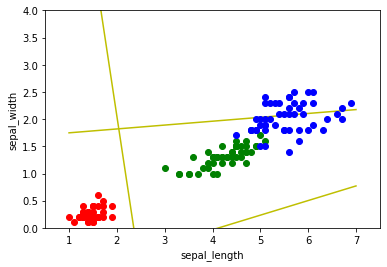

```python
my_softmax_regression.display(X, y)
```

```python
my_y_pred_proba, my_y_pred = my_softmax_regression.predict(X)
my_y_pred.shape
```

```
(150,)
```

```python
my_y_pred
```

```
array([0, 0, 0, 0, 0, 0, 0, 0, 0, 0, 0, 0, 0, 0, 0, 0, 0, 0, 0, 0, 0, 0,
       0, 0, 0, 0, 0, 0, 0, 0, 0, 0, 0, 0, 0, 0, 0, 0, 0, 0, 0, 0, 0, 0,
       0, 0, 0, 0, 0, 0, 1, 1, 1, 1, 1, 1, 1, 1, 1, 1, 1, 1, 1, 1, 1, 1,
       1, 1, 1, 1, 2, 1, 1, 1, 1, 1, 1, 1, 1, 1, 1, 1, 1, 1, 1, 1, 1, 1,
       1, 1, 1, 1, 1, 1, 1, 1, 1, 1, 1, 1, 2, 2, 2, 2, 2, 2, 2, 1, 2, 2,
       2, 2, 2, 2, 2, 2, 2, 2, 2, 1, 2, 2, 2, 2, 2, 1, 2, 2, 2, 1, 2, 2,
       2, 1, 1, 2, 2, 2, 2, 2, 2, 2, 2, 2, 2, 2, 2, 2, 2, 2])
```

### 3.3. Use `sklearn`

```python
from sklearn.linear_model import LogisticRegression
from sklearn.metrics import classification_report
```

```python
sklearn_logistic_regression = LogisticRegression(fit_intercept=False)
sklearn_logistic_regression
```

```
LogisticRegression(fit_intercept=False)
```

```python
sklearn_logistic_regression.fit(X, y)
```

```
LogisticRegression(fit_intercept=False)
```

```python
sklearn_logistic_regression.coef_
```

```
array([[ 3.90357538, -0.81657218, -1.57536381],
       [-0.21589691,  0.50595812, -0.60411622],
       [-3.68767847,  0.31061406,  2.17948002]])
```

```python
my_softmax_regression.w
```

```
array([[ 4.6171989 , -0.65906317, -4.42703628],
       [-1.9618402 ,  0.15962902, -0.18807667],
       [-0.33678468, -0.5938621 ,  2.63897931]])
```

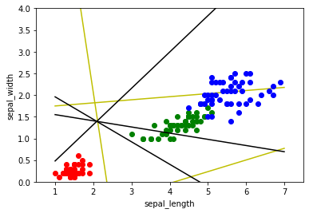

```python
my_softmax_regression.display(X, y, sklearn_logistic_regression.coef_.T)
```

```python
sklearn_y_pred = sklearn_logistic_regression.predict(X)
sklearn_y_pred.shape
```

```
(150,)
```

```python
print(classification_report(sklearn_y_pred, y))
```

```
              precision    recall  f1-score   support

      setosa       1.00      1.00      1.00        50
  versicolor       0.92      0.92      0.92        50
   virginica       0.92      0.92      0.92        50

    accuracy                           0.95       150
   macro avg       0.95      0.95      0.95       150
weighted avg       0.95      0.95      0.95       150
```

```python
print(classification_report(my_y_pred, y_index))
```

```
              precision    recall  f1-score   support

           0       1.00      1.00      1.00        50
           1       0.98      0.89      0.93        55
           2       0.88      0.98      0.93        45

    accuracy                           0.95       150
   macro avg       0.95      0.96      0.95       150
weighted avg       0.96      0.95      0.95       150
```

## 4. Homework